# Decision Tree analysis 3hr Pcr vs 24hr Pcr

Report produced By Cignpost Diagnostics Data Department

Waleed Idrees (Data Scientist) ,Ben Neffendorf (Head of Insight)

2021-10-14

# Executive Summary:

# Introduction

In this study we analyse attributes of customers that buy 3hr PCR and standard PCR tests. Data sample used for this study is only for Heathrow Terminals and starts from 03-09-2021, when we started offering 3hr PCR tests. We use descriptive statistics, exploratory data analysis to understand the data and in the end we use a **decision tree** to find out most important attributes for the customers who buy 3hr PCR tests.

# Data cleaning

summary statistics

| 3hr vs PCR Ratio before | 3hr vs PCR Ratio after |
| --- | --- |
| 4507 | 3320 |
| 22194 | 18568 |

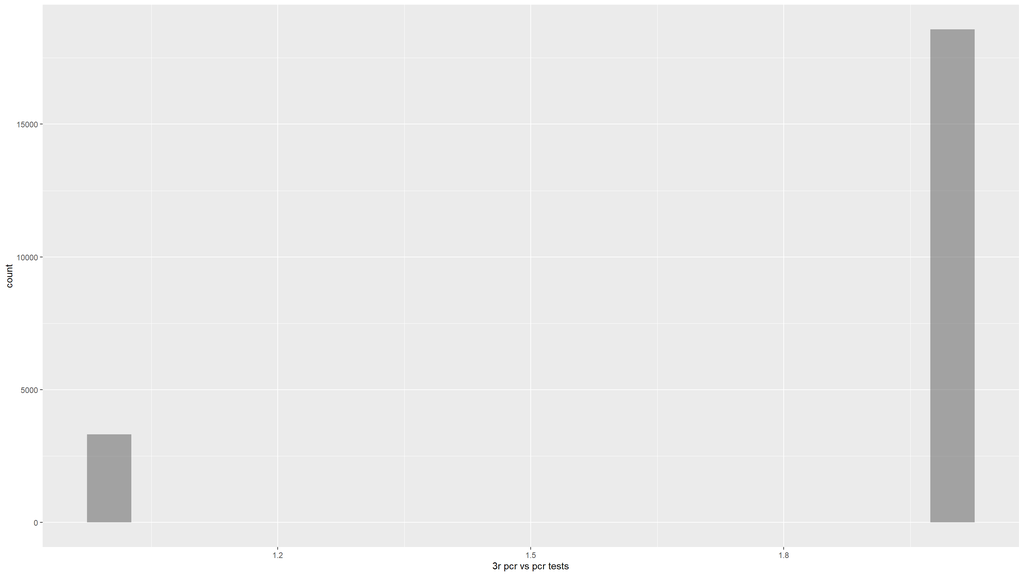

# Descriptive statistics Summary

desciptive statics 3hr pcr vs pcr

|  | age | booking_horizon | Lenght_In_Meters | partysize | test |
| --- | --- | --- | --- | --- | --- |
| Mean | 40.75 | 2.56 | 107.24 | 1.51 | 3hr pcr |
| Std.Dev | 17.10 | 5.97 | 138.01 | 0.93 | 3hr pcr |
| Median | 41.00 | 1.00 | 49.61 | 1.00 | 3hr pcr |
| Max | 158.00 | 147.00 | 1173.35 | 21.00 | 3hr pcr |
| Mean1 | 42.65 | 6.98 | 35.16 | 1.83 | pcr |
| Std.Dev1 | 17.81 | 11.24 | 65.54 | 1.00 | pcr |
| Median1 | 43.00 | 4.00 | 19.73 | 2.00 | pcr |
| Max1 | 100.00 | 370.00 | 1100.77 | 5.00 | pcr |

# Correlation

Correlation between tests and other variables

|  | technology_test |
| --- | --- |
| technology_test | 1.0000000 |
| booking_horizon | 0.1478672 |
| partysize | 0.1159315 |
| age | 0.0384746 |
| age_group | 0.0344581 |
| OAC_Supergroup_Name | 0.0117295 |
| sex | -0.0462782 |
| Lenght_In_Meters | -0.3047110 |
| cleaned_location | -0.5818585 |

Figure below shows the correlations between all our variables. Blue colour presents positive correlations and orange presents a negative correlations between two variables.

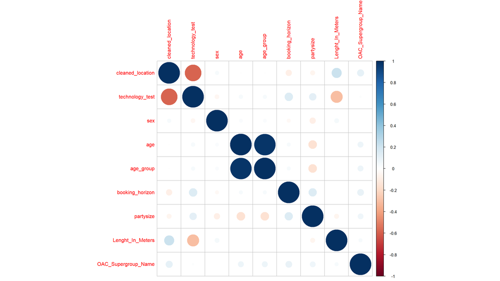

# Exploratiary Data Analysis

the figure below shows a comparison of number of 3hr PCR and PCR tests against sex, age, booking_horizon, partysize, Lenght_In_Meters, OAC_Supergroup_Name. We see a that highest tests are sold ti tge people aged between 25 to 65. and shorter the booking_horizon the more the number of tests. Most of the tests are sold to the party size smaller than 2.5. For PCR tests higher higher number of tets is associated with the smaller distance, However we notice that people who travel from longer distances prefer 3hr PCR test. In Subgroups multicultural metropolitans have the highest ratio of tests sold.

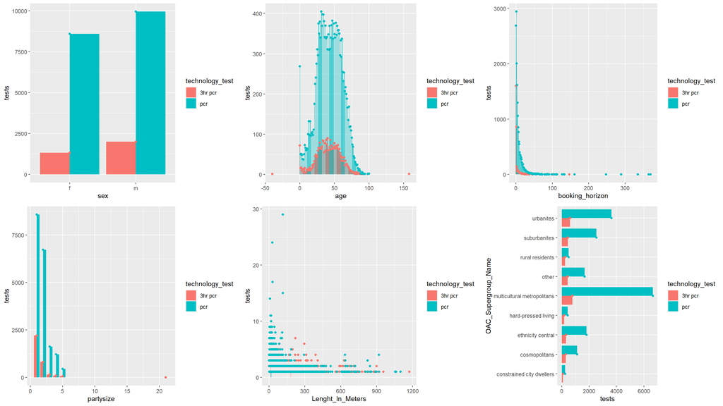

# Decision Tree

We construct a decision tree to understand the attributes bit better and to find out what are the most important factors and how do they effect the effect the choice of consumer. We trained a decision tree model with tree_depth 5 and min_n as 20, which is minimum number of data points in a node that are required for the node to be split further the goal is to keep the tree smaller so we can easily understand it.

# Variable Importance and Decision Tree

The most important variables in our model are presented by the figure below from most important to least important from top to bottom. Distance traveled, booking horizon and OAC_Supergroup rural variable, party size and age are the most important variables.

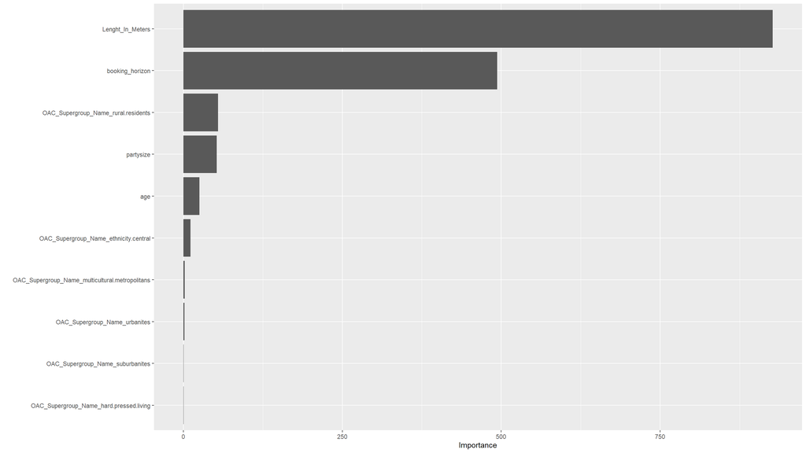

Lets have a look at the our decision tree graph. We can see that our tree has depth of 5. So the first variable starts with most important variable and contains 100% of samples. The first variable or the root node for our decision tree is Distance traveled. If distance traveled is greater than 66 we move to left branch if its not greater than 66 we move to right branch. Let take a look at the left side of our decision rule.

If distance traveled is greater than 66 we move to left branch now our decision tree looks at the next important variable if booking horizon is smaller than 1.5 we move to left branch, if age is smaller than 77 we move to next variable and the process continues untill the data cannot be divided into further subsets.

the green colour tells us that in the node higher proortion is of 3hr PCR and blue tells us that higher proportion is of PCR test. as we look at the outer most left branch of our decision Tee we notice that as we go down the tree our proportion for the 3hr tests is getting increased compared to the PCR test.

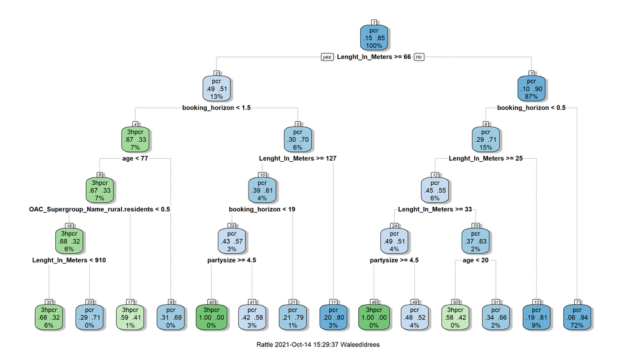

in the tables below i have produced decision tree out put for left side and right side rules.

| Subrule | Variable | Value | Less | Greater |
| --- | --- | --- | --- | --- |
| L1 | Lenght_In_Meters | 65.977 | NA | 65.977 |
| L2 | booking_horizon | NA | 1.5 | NA |
| L3 | age | NA | 76.5 | NA |
| L4 | OAC_Supergroup_Name_rural.residents | NA | 0.5 | NA |
| L5 | Lenght_In_Meters | NA | 909.867 | NA |
| L6 | Lenght_In_Meters | 127.388 | NA | 127.388 |
| L7 | booking_horizon | NA | 18.5 | NA |
| L8 | partysize | 4.5 | NA | 4.5 |
| L9 | booking_horizon | NA | 0.5 | NA |
| L10 | Lenght_In_Meters | 25.2215 | NA | 25.2215 |
| L11 | Lenght_In_Meters | 33.2265 | NA | 33.2265 |
| L12 | partysize | 4.5 | NA | 4.5 |
| L13 | age | NA | 19.5 | NA |

| Subrule | Variable | Value | Less | Greater |
| --- | --- | --- | --- | --- |
| R1 | Lenght_In_Meters | NA | 65.977 | NA |
| R2 | booking_horizon | 1.5 | NA | 1.5 |
| R3 | age | 76.5 | NA | 76.5 |
| R4 | OAC_Supergroup_Name_rural.residents | 0.5 | NA | 0.5 |
| R5 | Lenght_In_Meters | 909.867 | NA | 909.867 |
| R6 | Lenght_In_Meters | NA | 127.388 | NA |
| R7 | booking_horizon | 18.5 | NA | 18.5 |
| R8 | partysize | NA | 4.5 | NA |
| R9 | booking_horizon | 0.5 | NA | 0.5 |
| R10 | Lenght_In_Meters | NA | 25.2215 | NA |
| R11 | Lenght_In_Meters | NA | 33.2265 | NA |
| R12 | partysize | NA | 4.5 | NA |
| R13 | age | 19.5 | NA | 19.5 |

# Model Accuracy and Confusion Matrix

Our matrics for accuracy and roc_auc are pretty good for this data look good accuracy tells us over all our model is predicting 86% of the catagories of tests correctly. But since our 3hr pct sample is very small and data is imbalanced and we didn’t do anything to take care of class imbalance so there is a high chance that we will get better predictions for PCR as higher data for PCR will favor PCR tests.

| .metric | .estimator | .estimate | .config |
| --- | --- | --- | --- |
| accuracy | binary | 0.8698036 | Preprocessor1_Model1 |
| roc_auc | binary | 0.7826102 | Preprocessor1_Model1 |

Lets look at the confusion matrix, which shows how many of predictions are correct by checking them against the original values in the test set. As suspected due to class imbalance we see that from our testing set out of 664 observatons of 3hr PCR we only predicted 246 correctly and 418 are incorrectly predicted. However for PCR out of 3714 our model correctly predicted 3562.

```
#>           Truth
#> Prediction 3hpcr  pcr
#>      3hpcr   246  152
#>      pcr     418 3562
```

Lets have a look at the roc curves. ROC curve y axis shows the True positive rate or sensitivity and x-axis shows False positive rate also known as 1-specificity.

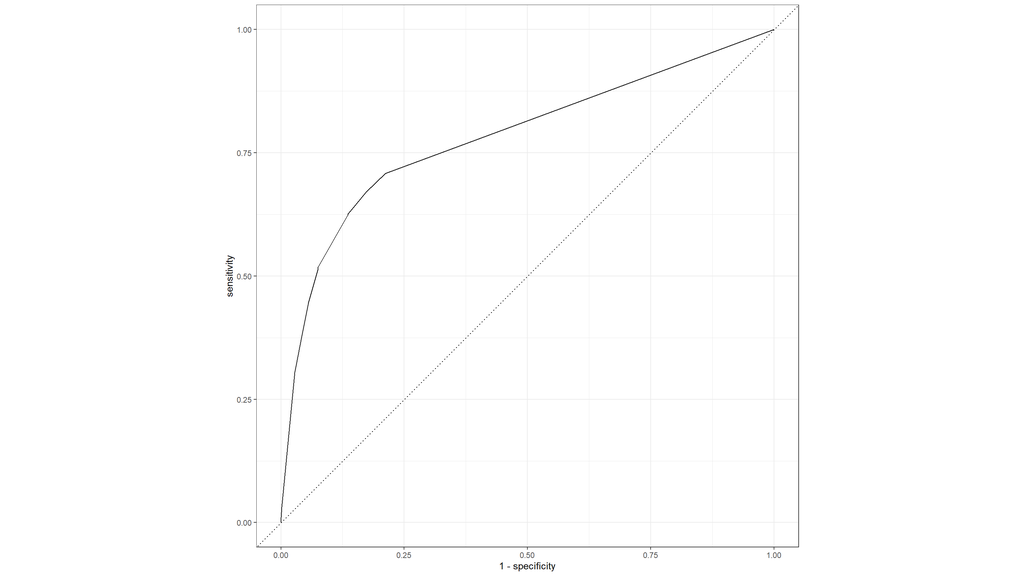